# Assessment 2

14088355 Yiyan Gao

## Assessment Task 2

Design and implement a novel solution, defining appropriate questions and metrics, and incorporating data acquisition pipelines, interactive visualisation and appropriate analytics to answer the defined questions. Write a short online, interactive report to describe the outcome and provide the solution in a form appropriate for a wide audience. Reflect on your chosen solution and on alternative possible solutions for the problem you have chosen.

An implementation process might go something like this.

Find a dataset with some interesting data. There are many sources for data that I’ve already given you. You can use an inbuilt R dataset if that suits you, but many external datasets will hold more interesting questions. Check that the data is clean, that means it is not missing any values, and that the format is correct and easily understandable. Define some worthwhile questions which might have multiple options for answers. Define the data that can help to answer those questions. Place each question in its own ‘chunk’. Develop an analysis that can answer the question within the chunk, with an output that is appropriate to the question (eg graphic, single value, table, etc.). Add a short Introduction and a Conclusion to the report. Add your reflection as an appendix.

# New York Air Quality Measurements

```r
library(dplyr)
library(gridExtra)
library(ROCR)
library(tidyverse)
library(caret)
library(moments)
```

1. Check the first rows of the dataset 1.1 Load data

```r
data(airquality)
```

1.2 Check the dimension of the dataset

```r
dim(airquality)
```

```
## [1] 153   6
```

1.3 Show first few rows of the dataset

```r
head(airquality)
```

```
##   Ozone Solar.R Wind Temp Month Day
## 1    41     190  7.4   67     5   1
## 2    36     118  8.0   72     5   2
## 3    12     149 12.6   74     5   3
## 4    18     313 11.5   62     5   4
## 5    NA      NA 14.3   56     5   5
## 6    28      NA 14.9   66     5   6
```

1.4 Check the type of the data in each column

```r
sapply(airquality, class)
```

```
##     Ozone   Solar.R      Wind      Temp     Month       Day
## "integer" "integer" "numeric" "integer" "integer" "integer"
```

2. Missing value handling and data cleaning 2.1 Check if the data is clean, that means it is not missing any values 2.1.1 Check duplicated rows

```r
sum(duplicated(airquality))
```

```
## [1] 0
```

2.1.2 Check values that are na

```r
sum(!complete.cases(airquality))
```

```
## [1] 42
```

2.1.3 Check the numnber of na values in each column

```r
sapply(airquality, function(x) sum(is.na(x)))
```

```
##   Ozone Solar.R    Wind    Temp   Month     Day
##      37       7       0       0       0       0
```

2.2 Remove rows with missing values

```r
df <- na.omit(airquality)
```

Show that there is no null values

```r
sum(!complete.cases(df))
```

```
## [1] 0
```

2.3 Change Month and Day to factor variables

```r
df$Month <- factor(df$Month, levels=5:9, labels=month.abb[5:9], ordered=TRUE)
df$Day <- factor(df$Day, levels=c(1:31), ordered=TRUE)
```

3. Explorative Data Analysis 3.1 Describe the dataset 3.1.1 Dimension of the dataset

```r
dim(df)
```

```
## [1] 111   6
```

3.1.2 Summary of the dataset

```r
summary(df)
```

```
##      Ozone          Solar.R           Wind            Temp       Month
##  Min.   :  1.0   Min.   :  7.0   Min.   : 2.30   Min.   :57.00   May:24
##  1st Qu.: 18.0   1st Qu.:113.5   1st Qu.: 7.40   1st Qu.:71.00   Jun: 9
##  Median : 31.0   Median :207.0   Median : 9.70   Median :79.00   Jul:26
##  Mean   : 42.1   Mean   :184.8   Mean   : 9.94   Mean   :77.79   Aug:23
##  3rd Qu.: 62.0   3rd Qu.:255.5   3rd Qu.:11.50   3rd Qu.:84.50   Sep:29
##  Max.   :168.0   Max.   :334.0   Max.   :20.70   Max.   :97.00
##
##       Day
##  7      : 5
##  9      : 5
##  13     : 5
##  16     : 5
##  17     : 5
##  18     : 5
##  (Other):81
```

3.2 Distribution of Ozone 3.2.1 Histogram of Ozone

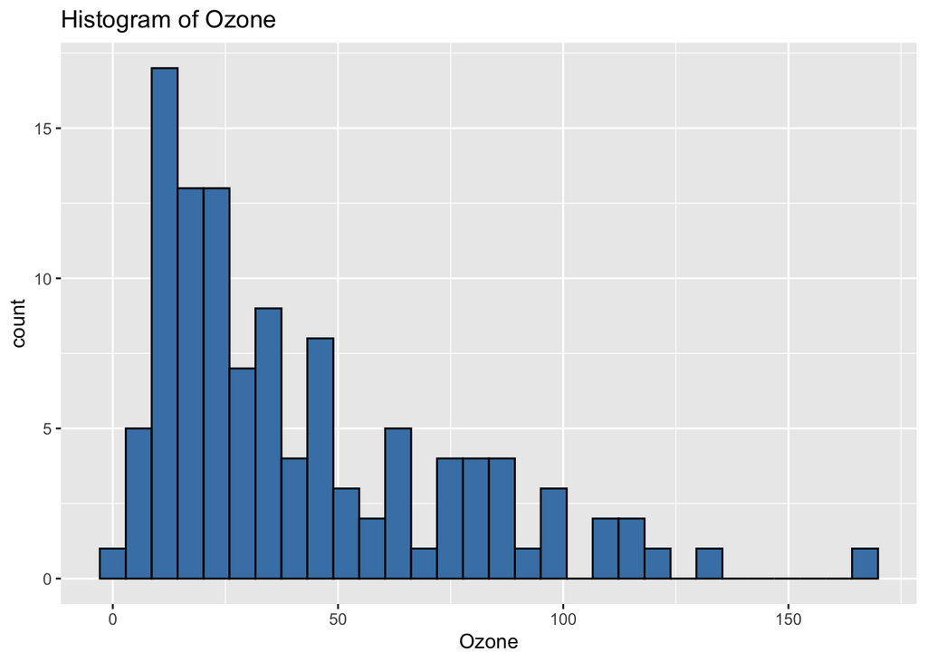

```r
ggplot(data=df, aes(x=Ozone)) +
  geom_histogram(fill="steelblue", color="black") +
  ggtitle("Histogram of Ozone")
```

3.2.2 Check the skewness

```r
skewness(df$Ozone, na.rm = T)
```

```
## [1] 1.248104
```

3.2.3 Check the kurtosis

```r
kurtosis(df$Ozone, na.rm=T)
```

```
## [1] 4.204408
```

3.24 Scale Ozone for more symmetric distribution

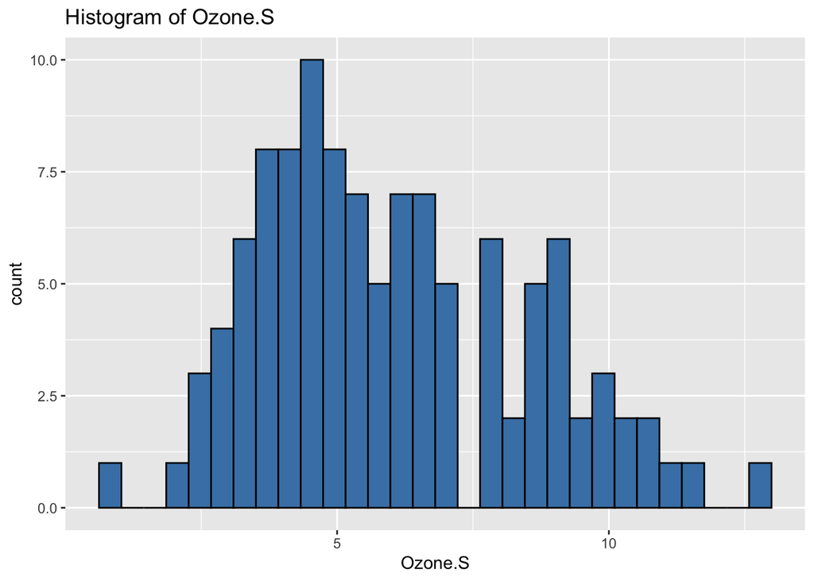

```r
df$Ozone.S <- sqrt(df$Ozone)
ggplot(data=df, aes(x=Ozone.S)) +
  geom_histogram(fill="steelblue", color="black") +
  ggtitle("Histogram of Ozone.S")
```

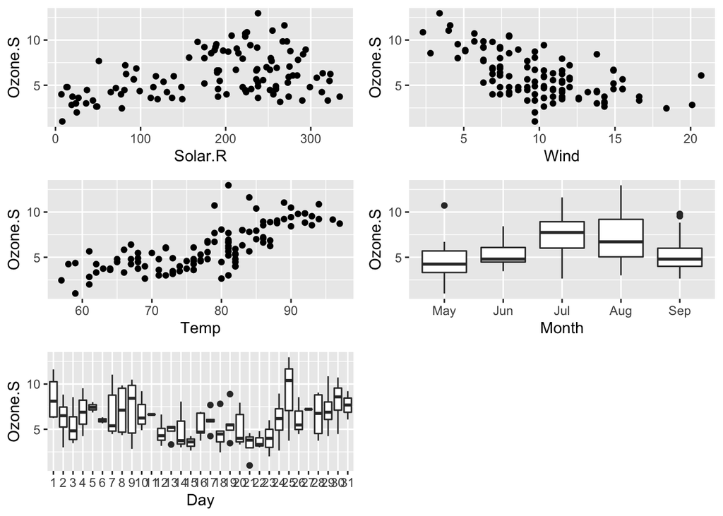

```r
p1 <- ggplot(df, aes(x=Solar.R, y=Ozone.S)) + geom_point()
p2 <- ggplot(df, aes(x=Wind, y=Ozone.S)) + geom_point()
p3 <- ggplot(df, aes(x=Temp, y=Ozone.S)) + geom_point()
p4 <- ggplot(df, aes(x=Month, y=Ozone.S)) + geom_boxplot()
p5 <- ggplot(df, aes(x=Day, y=Ozone.S)) + geom_boxplot()
grid.arrange(p1, p2, p3, p4, p5, nrow = 3)
```

3.4 Pair plot for all numeric variables

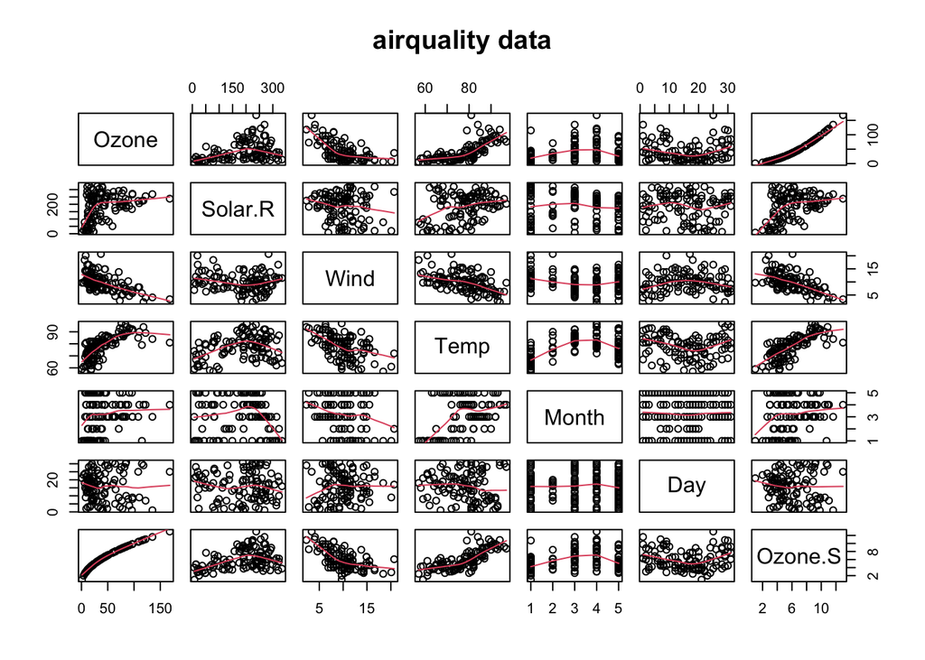

```r
pairs(df, panel = panel.smooth, main = "airquality data")
```

3.5 Check the correlations between variables

```r
# Choose the numerical columns
columns <- c('Ozone.S', 'Solar.R', 'Wind', 'Temp')
round(cor(df[, columns]), 2)
```

```
##         Ozone.S Solar.R  Wind  Temp
## Ozone.S    1.00    0.40 -0.61  0.75
## Solar.R    0.40    1.00 -0.13  0.29
## Wind      -0.61   -0.13  1.00 -0.50
## Temp       0.75    0.29 -0.50  1.00
```

Ozone is moderately correlated with Solar.R, strongly correlated with Wind, strongly correlated to Temperature. Solar.R is weakly correlated with Wind and Temp. Wind is moderately correlated to Temp.

4. Train a linear regression model and evaluate the model 4.1 Train the model

```r
set.seed(0)
training.samples <- df$Ozone.S %>%
  createDataPartition(p = 0.8, list = FALSE)
train.data  <- df[training.samples, ]
test.data <- df[-training.samples, ]

model <- lm(Ozone.S ~., data = train.data)
summary(model)
```

```
##
## Call:
## lm(formula = Ozone.S ~ ., data = train.data)
##
## Residuals:
##     Min      1Q  Median      3Q     Max
## -1.1268 -0.1761  0.0244  0.1993  0.7376
##
## Coefficients:
##               Estimate Std. Error t value Pr(>|t|)
## (Intercept)  1.6254573  1.0668349   1.524   0.1338
## Ozone        0.0632931  0.0034784  18.196   <2e-16 ***
## Solar.R      0.0016818  0.0007629   2.204   0.0320 *
## Wind        -0.0268263  0.0251527  -1.067   0.2912
## Temp         0.0211119  0.0138530   1.524   0.1337
## Month.L      0.0859518  0.1588578   0.541   0.5908
## Month.Q     -0.0124566  0.1740593  -0.072   0.9432
## Month.C     -0.0204245  0.1747793  -0.117   0.9074
## Month^4      0.0415887  0.1578830   0.263   0.7933
## Day.L       -0.1502447  0.3185613  -0.472   0.6392
## Day.Q        0.3475468  0.3431347   1.013   0.3159
## Day.C        0.3177931  0.3163896   1.004   0.3199
## Day^4       -0.0002881  0.3109839  -0.001   0.9993
## Day^5       -0.1275349  0.3213574  -0.397   0.6931
## Day^6       -0.1206007  0.3011423  -0.400   0.6905
## Day^7        0.0039286  0.2948130   0.013   0.9894
## Day^8        0.4835540  0.3146763   1.537   0.1306
## Day^9        0.3356266  0.3168084   1.059   0.2944
## Day^10       0.1846969  0.3095229   0.597   0.5533
## Day^11      -0.3428351  0.3386625  -1.012   0.3162
## Day^12      -0.3129074  0.2988774  -1.047   0.3001
## Day^13       0.3153724  0.3318103   0.950   0.3464
## Day^14      -0.6553144  0.3230225  -2.029   0.0477 *
## Day^15      -0.7501906  0.3363403  -2.230   0.0301 *
## Day^16       0.1531726  0.2981657   0.514   0.6097
## Day^17       0.1998891  0.3071259   0.651   0.5181
## Day^18       0.2353128  0.3557839   0.661   0.5113
## Day^19       0.1643147  0.3245588   0.506   0.6148
## Day^20       0.3274638  0.3209267   1.020   0.3124
## Day^21      -0.0840847  0.3283388  -0.256   0.7989
## Day^22      -0.2818712  0.3315140  -0.850   0.3992
## Day^23      -0.1614824  0.3281280  -0.492   0.6247
## Day^24      -0.3148125  0.3285737  -0.958   0.3425
## Day^25      -0.0371455  0.2932756  -0.127   0.8997
## Day^26      -0.2993357  0.3549629  -0.843   0.4030
## Day^27       0.1339975  0.3072272   0.436   0.6646
## Day^28       0.1062998  0.2769053   0.384   0.7027
## Day^29      -0.4313167  0.2896192  -1.489   0.1426
## Day^30       0.2095570  0.2970902   0.705   0.4838
## ---
## Signif. codes:  0 '***' 0.001 '**' 0.01 '*' 0.05 '.' 0.1 ' ' 1
##
## Residual standard error: 0.4678 on 51 degrees of freedom
## Multiple R-squared:  0.9807, Adjusted R-squared:  0.9662
## F-statistic: 68.04 on 38 and 51 DF,  p-value: < 2.2e-16
```

```r
saveRDS(model, "model.rds")
```

4.2 Evaluation of th model

```r
predictions <- model %>% predict(test.data)
RMSE(predictions, test.data$Ozone.S)
```

```
## [1] 0.564245
```

```r
R2(predictions, test.data$Ozone.S)
```

```
## [1] 0.9399618
```

```r
library(shiny)
ui<- fluidPage(
titlePanel(title=" Air Quality Prediction "),
sidebarLayout(
sidebarPanel(
  sliderInput('solar', 'Solar Radiation', min=7, max=334, value=7, step=1, round=0),
  sliderInput('wind', 'Wind', min=2, max=21, value=2, step=1, round=0),
  sliderInput('temp', 'Temperature', min=55, max=100, value=1, step=0.1, round=0),
  selectInput('month', 'Month', c('May', 'Jun', 'Jul', 'Aug', 'Sep')),
  selectInput('day', 'Day', c(1:31)),
),
mainPanel(
  h3(textOutput('title')),
  verbatimTextOutput('result')
))
)
server<- function (input, output){
  data <- reactive({
    data.frame(Solar.R=input$solar,
               Wind=input$wind,
               Temp=input$temp,
               Month=input$month,
               Day=input$day,
               Ozone=0
               )
  })

  prediction <- reactive({
    predict(model, newdata = data())
  })

  t <- "Predicted Air Quality:"

  output$title <- renderText(t)

  output$result <- renderText(prediction())
}

shinyApp (ui = ui , server = server )
```

Shiny applications not supported in static R Markdown documents